# ISA 401: Business Intelligence & Data Visualization

### Fall 2026

# Before We Start

<countdown-timer class="countdown" id="timer_d7fe8061" minutes="4" seconds="0" update-every="1" tabindex="0" style="top:0;right:0;--countdown-font-size:2em;"></countdown-timer>

1 Join today's Zoom

Use the Zoom link in the [**Week 0 Module**](https://miamioh.instructure.com/courses/258169/modules/981092) on Canvas. **Mute** your mic and **turn off** your video.  
Please log in from the lab's computer so you have the option to share your screen if you need help debugging an error.

2 Install GitHub Desktop

Run the **GitHub Desktop** installer: it is on the lab computer's Desktop, or type *GitHub Desktop* in the Windows search bar.  
It installs in about a minute and opens by itself.

3 Sign in

**Sign in to GitHub.com** with the account you created in **Assignment 0**.  
Your browser opens, you authorize, and it hands you back to Desktop.

4 Configure Git

When asked, keep the **name** and **email** you use on GitHub, then click **Finish**.  
This is what stamps your name on every snapshot you save.

Done early? **Help the person next to you.** Stuck? **Share your screen on Zoom** and we fix it together. Nobody sinks in this class; **everyone swims.**

# Quick Refresher from Last Class

The Analytics Journey

Pre-analytics get and clean the data

Descriptive what happened?

Predictive what will happen?

Prescriptive what should we do?

**BI** lives in the first two, and feeds the rest.

One Job Ad, Three Shapes

Unstructured the ad text

Semi-structured the skills JSON

Structured the database row

Most of this course moves data from top to bottom.

Habits We Practiced

**Unit of analysis:** rows ≠ crashes

**Counts vs. rates:** a busy weekday is not a risky one

**Provenance:** who collected this, and how?

**Encodings:** position, length, color, shape

Today we start doing all of this in code.

# Learning Objectives for Today's Class

- **Explain** why scripted languages enable **reproducible analysis**.

- **Use** R **syntax, data structures, and functions**.

- **Set up** an R **project** with a proper workflow.

- **Initialize and use Git** for version control.

Part 1

Why scripts?

Spreadsheets that broke, and code that re-runs

Part 2

Git + GitHub

Snapshots, commits, and your first repo

Part 3

Your R project

RStudio inside your repo, relative paths, first push

Part 4

R 101

Objects, vectors, data frames, functions

The first half is setup-heavy on purpose: every script you write from Part 4 onward lives in the repo you create in Part 2.

# Why Scripts?

# Spreadsheets That Made the News

<html>
<hr>
</html>
- **There is always more:** a 2024 review of 35 years of studies reports that **94% of the business spreadsheets audited in those studies contained errors** ([Poon et al. (2024), *Frontiers of Computer Science*](https://link.springer.com/article/10.1007/s11704-023-2384-6)).
- The Guardian keeps a running [bloopers reel](https://www.theguardian.com/technology/2024/oct/28/microsoft-excels-bloopers-reel-40-years-of-spreadsheet-errors) of spreadsheet errors going back to 1985.

# The Same Chart in a Spreadsheet and in R

The crashes-by-weekday chart from Class 01, built twice from the same CSV. The chart is identical. The **record of how it was made** is not.

In a spreadsheet

**1.** Download the crash CSV from the open-data portal

**2.** Open it in Excel

**3.** One crash spans several rows: Data → Remove Duplicates on `instanceid`

**4.** Add a weekday column with `=TEXT(B2,"ddd")`, drag it down

**5.** Insert a pivot table; count rows by weekday

**6.** Insert a bar chart; paste it into PowerPoint

Now do it by month instead of weekday. Which of these steps do you redo?

In R

```
crashes = readr::read_csv("data/cincy_2025_crashes.csv") |>  dplyr::mutate(    datetime = lubridate::ymd_hms(crashdate),    weekday  = lubridate::wday(datetime, label = TRUE)  ) |>  dplyr::distinct(instanceid, .keep_all = TRUE) crashes |>  dplyr::count(group = weekday) |>  ggplot2::ggplot(    ggplot2::aes(x = n, y = forcats::fct_rev(group))  ) +  ggplot2::geom_col(fill = "#C3142D") +  ggplot2::labs(x = "Crashes", y = NULL,                title = "Cincinnati crashes in 2025")
```

# Changes to Unit of Analysis are Easier in R

.panel[By weekday

```
crashes |>  dplyr::count(group = weekday) |>  ggplot2::ggplot(    ggplot2::aes(x = n, y = forcats::fct_rev(group))  ) +  ggplot2::geom_col(fill = "#C3142D") +  ggplot2::geom_text(    ggplot2::aes(label = scales::comma(n)),    hjust = -0.15, size = 3  ) +  ggplot2::scale_x_continuous(    expand = ggplot2::expansion(mult = c(0, 0.18))  ) +  ggplot2::labs(x = "Crashes", y = NULL,                title = "Cincinnati crashes in 2025")
```

[figure not shown]

.panel[By month

```
crashes |>  dplyr::count(group = month) |>  ggplot2::ggplot(    ggplot2::aes(x = n, y = forcats::fct_rev(group))  ) +  ggplot2::geom_col(fill = "#C3142D") +  ggplot2::geom_text(    ggplot2::aes(label = scales::comma(n)),    hjust = -0.15, size = 3  ) +  ggplot2::scale_x_continuous(    expand = ggplot2::expansion(mult = c(0, 0.18))  ) +  ggplot2::labs(x = "Crashes", y = NULL,                title = "Cincinnati crashes in 2025")
```

[figure not shown]

# Code Is Just Text

Programming languages are **languages**. Code is **just text**, which hands you two extremely powerful techniques:

`Ctrl` + `C`

`Ctrl` + `V`

Readable

You can read what someone did, top to bottom. Try that with a pivot table.

Open

An error message is text too: search it, or paste it into [ChatISA](https://chatisa.fsb.miamioh.edu/).

Reusable

New month, new file: change one line and re-run. Someone else gets the same result.

Diffable

Text can be compared line by line, so a tool can show you exactly what changed, and when. That tool is next.

<html>
<hr>
</html>
**Source:** Based on [Hadley Wickham's You Can't Do Data Science in a GUI](https://speakerdeck.com/hadley/you-cant-do-data-science-in-a-gui?slide=14), slides 14 to 17.

# Git + GitHub

# Git in Currently Open ISA Jobs

[figure not shown]

| Employer | Role | Location | Posted |
| --- | --- | --- | --- |
| Apple | [Product Data Scientist, Employee Experience & Pro...](https://jobs.apple.com/en-us/details/200677976) | Sunnyvale CA | Aug 19 |
| Booz Allen Hamilton | [Data Engineer](https://bah.wd1.myworkdayjobs.com/BAH_Jobs/job/San-Diego-CA/Data-Engineer_R0246048) | San Diego CA | Aug 05 |
| CapTech Consulting | [Data Analyst](https://jobs.smartrecruiters.com/CapTechConsulting/744000144138659-data-analyst) | Columbus OH | Aug 18 |
| U.S. Soccer Federation | [Data Scientist, Business Ventures](https://recruiting.paylocity.com/Recruiting/Jobs/Details/4442922) | Atlanta GA | Aug 22 |

<html>
<hr>
</html>
- **Chart:** every posting collected by [ChatISA Job Scout](https://chatisa.fsb.miamioh.edu/) from Jun 30 to Aug 23, 2026 (1,891 postings). A posting "mentions Git" if its skills tag includes version control or its text names git, GitHub, GitLab, or Bitbucket.
- **Table:** four of the 32 open postings that ask for **both R and Git** (links checked Aug 25, 2026). Chart and table are computed from the database by code inside this deck.

# Git is Heavily Used by AI Harnesses

What an AI coding agent does when you hand it a task, as the vendors themselves describe it (sources below). The terminal is a simplified mock-up; the six steps loop. Click the animation to pause it.

1 · You

Describe the task

2 · Agent

Creates a branch

3 · Agent

Edits the code

4 · Agent

Commits a snapshot

5 · Agent

Pushes and opens a PR

6 · You

Review, then merge

<html>
<hr>
</html>
- **Claude Code:** a mention of `@claude` on GitHub can "implement changes, and push commits" and "turn issues into pull requests" ([Anthropic docs](https://code.claude.com/docs/en/github-actions)).
- **Codex:** works in an isolated copy of your repository, then lets you "open a pull request when the work is ready" ([OpenAI docs](https://learn.chatgpt.com/docs/cloud)).
- **GitHub Copilot coding agent:** makes "code changes on a branch" and opens a pull request for a person to review ([GitHub docs](https://docs.github.com/en/copilot/concepts/agents/coding-agent/about-coding-agent)).

# Git vs GitHub

Git

A **program on your computer** that keeps **snapshots of a folder**.

Created in **2005** by Linus Torvalds to manage the Linux kernel's source code. Free and open source.

Works with no internet connection. GitHub Desktop, RStudio, and VS Code are all just buttons on top of it.

GitHub

A **website** that **hosts Git folders** so people can share, review, and publish them.

Owned by Microsoft since **2018**. More than **180 million users**. Free for what we do.

Your `business_intelligence` repo from Assignment 0 lives here. Employers look here.

**Git** is the tool. It runs on your machine and works offline.

**GitHub** is the place. Copies live there so they can be shared, reviewed, and published.

You can use Git without GitHub. You cannot use GitHub without Git.

<html>
<hr>
</html>
- **Git's origin:** the official Git book, [A Short History of Git](https://git-scm.com/book/en/v2/Getting-Started-A-Short-History-of-Git).
- **Ownership:** [Microsoft completes GitHub acquisition](https://blogs.microsoft.com/blog/2018/10/26/microsoft-completes-github-acquisition/), Oct 26, 2018.
- **Users:** [GitHub Octoverse 2025](https://github.blog/news-insights/octoverse/octoverse-a-new-developer-joins-github-every-second-as-ai-leads-typescript-to-1/), "180 million-plus developers."

# Git's Terminology

| Word | Means |
|:--|:--|
| **repository** (repo) | a folder Git watches |
| **commit** | a named snapshot of that folder |
| **push** / **pull** | upload / download snapshots to or from GitHub |
| **branch** | a parallel copy for work in progress |
| **pull request** | "please merge my branch," plus discussion |
| **merge** | accept it into `main` |

[figure not shown]

# What You Did in Assignment 0

On github.com, in your browser, you did three things. Each one has a Git word:

1 New repository

You named it `business_intelligence` and made it public.

That created a **repository**: a folder GitHub watches.

→

2 Add README.md

You wrote your name and the course topics into the file.

Git does not know about a file until it is committed.

→

3 Commit changes

The green button at the bottom of the editor.

That was your first **commit**: a named snapshot. GitHub made it for you, on its servers.

So far the repo exists in **one place: GitHub**. No computer has a copy, and every edit went through a web page. Real work (R scripts, data, plots) happens on a computer, so the next step is to bring the repo **down** to this one: **clone**. After that, three new verbs: **change, commit, push**.

# Live Demo: Clone, Change, Commit and Push

Follow along on your lab computer. I do each step on the screen first, then you do it.

.panel[Steps

**1 Clone.** GitHub Desktop → **File → Clone repository** → pick `YOUR-USERNAME/business_intelligence`. Set **Local path** to `M:\isa401\` (your M: drive follows you to any lab computer; we open this folder in RStudio next). Click **Clone**.

**2 Change.** **Repository → Show in Explorer**. Open `README.md` in Notepad. Under *About Me* add one line, then save:

- **Tools this semester:** R, RStudio, Git

**3 Commit.** Back in Desktop, **look at the diff**: your new line is green, and the checkbox next to `README.md` is ticked. Summary: `Add tools line`. Click **Commit to main**.

**4 Push.** Click **Push origin**.

**5 Verify.** **Repository → View on GitHub**. Refresh. Your line is there and the repo now shows **2 commits**.

If you fall behind

Say so, or **share your screen on Zoom**. Nobody moves on until everyone has pushed.

The usual issues:

- Desktop is signed in to the wrong account: **File → Options → Accounts**
- Notepad saved the file as `README.md.txt`: turn on file extensions in Explorer
- Repo not listed under Clone: paste the URL `https://github.com/YOUR-USERNAME/business_intelligence`

.panel[Checkpoint

**After step 1:** Desktop's title bar says `business_intelligence`, and `M:\isa401\business_intelligence\README.md` exists in Explorer.

**After step 2:** Desktop's left pane lists `README.md` under *1 changed file* with its checkbox ticked; the right pane shows your line highlighted in green with a `+` in front of it. Nothing is red, because you only added.

**After step 3:** the left pane says *0 changed files*, and the **History** tab lists two commits: yours on top, the one you made on the website below.

**After step 4:** the top bar changes from *Push origin, 1* to *Fetch origin*. The commit has left this computer.

**After step 5:** on GitHub, the README shows the line, and the commit counter near the top of the file list reads **2 commits**. Click it to see both snapshots.

.panel[Discussion

- Notes from our class discussion (Use Chrome as your browser to edit this part of the page)

# Publish a Career Portfolio with ChatISA

.panel[Steps

1 Sign in

Go to [**chatisa.fsb.miamioh.edu/portfolio**](https://chatisa.fsb.miamioh.edu/portfolio) and **Sign in with GitHub**, authorizing ChatISA to act on your account.

→

2 Fill in the builder

Your **name**, a **headline**, a **photo**, and **2 to 3 projects**. Click **Generate**.

ChatISA drafts the page text with AI, creates a repository named `portfolio` on your GitHub, and publishes it.

→

3 Open it

On your phone: `https://YOUR-USERNAME.github.io/portfolio/` (allow about a minute).

A website with your name on it, hosted by GitHub, from a repo you now own.

**What you have now is a first draft.** In **Assignment 02** you make it yours, one commit at a time: read every AI-generated sentence and edit it so it is accurate and sounds like you, add your contact links, keep only the projects you would defend in an interview, and reorder the sections (it is your name on the page, and recruiters will read it).

Then answer the poll on the next tab: **which Git verbs did ChatISA just run on your behalf?** Full walkthrough of the builder: youtu.be/I85EeVFfkEo.

.panel[Poll

[interactive chart not shown]

.panel[Discussion

- Notes from our class discussion (Use Chrome as your browser to edit this part of the page)

# Text Files vs Binary Files

Text

**Code, CSV, Markdown, .R, .Rmd, .qmd, HTML**

Git stores the **lines**. Desktop shows a red/green diff. The history is readable years later. Two people can merge, line by line.

Binary

**.xlsx, .pptx, .docx, .png, .pdf**

Git stores the **whole file**, every commit. Desktop says "Binary file not shown." No line-by-line merge: someone loses. The repo gets heavy, fast.

2 changed files

data/cincy_2025_crashes.csv +2 −1

report.pptx binary

data/cincy_2025_crashes.csv

@@ -8,3 +8,4 @@ instanceid,crashdate,weather

C7450B16,2025-01-01T00:15,4 - RAIN

-B956B8CC,2025-01-01T00:01,99 - OTHER/UNKNOWN

+B956B8CC,2025-01-01T00:01,1 - CLEAR

+A1D3F0E7,2025-01-01T00:40,2 - CLOUDY

report.pptx

Binary file not shown.

**Rule of thumb:** data as CSV, code and notebooks as text, and keep the big binaries out of the repo (share them from Google Drive and link to them).

# Fixing Mistakes

Before you push: Undo

A commit you have not pushed is still **private to this computer**. GitHub has never seen it.

In Desktop, under the commit button: click **Undo**. The commit disappears and the changes come back to the left pane, so you can fix them and commit again.

Typo in the message? Committed the wrong file? Undo.

After you push: Revert

Once pushed, the commit is on GitHub, and possibly on a teammate's machine. **Git never deletes history.**

In Desktop's **History** tab: right-click the commit → **Revert changes in commit** → Push origin. Revert is a **new commit that flips the old one**. Both stay in the log.

Deleted a section by accident and already pushed? Revert.

**Git is a time machine.** Nothing you commit is ever really lost. That is exactly why you should **commit early and commit often**, and stop keeping `final_v3_REALLY_final.xlsx` on your desktop. The filename was doing this job, badly.

# Your R Project

# The RStudio Interface

[figure not shown]

**1** Source: scripts **2** Console: R runs here **3** Environment (and the Git tab) **4** Files, Plots, Packages, Help, Viewer **5** Project name **6** Run

# Set Up RStudio Once

.panel[1 R version

[figure not shown]

General → R version

Should read **4.6.0 or newer**. This one is 4.6.1.

**Why it matters:** if a computer has more than one R installed, RStudio may be pointed at an old one. Click **Change...** and pick the newest, or your packages and results will quietly differ from mine.

.panel[2 Workspace

[figure not shown]

General → Workspace

**Restore .RData into workspace at startup:** unchecked.

**Save workspace to .RData on exit:** Never.

**Why:** every session starts with an empty Environment. Anything you need has to come from a script you can re-run, which is the promise from Part 1. The alternative is an invisible `.RData` file that quietly carries yesterday's objects into today.

.panel[3 Pipe

[figure not shown]

Code → Editing

**Use native pipe operator, `|>`:** checked.

Ctrl + Shift + M then types `|>`.

**Why:** every pipeline in this course is written with `|>` (you saw it on the crash-data slides). The older `%>%` still works, but we will not use it.

.panel[4 Highlighting

[figure not shown]

Code → Display

**Highlight R function calls:** checked.

**Use rainbow parentheses:** checked.

**Optional, but helpful:** function names get their own color (that is how the code on these slides is colored), and each nesting level of parentheses gets its own color, so a missing `)` is easy to spot.

.panel[5 Appearance

[figure not shown]

Appearance

**Editor font size:** 16, bigger than the default.

**Editor theme:** Tomorrow Night Bright, if you want it.

**Optional:** the theme gives you the same colors as my screen for functions, packages, and parentheses, which makes following along easier. The font size is for your eyes and your neighbor's.

# What Is a Project?

A self-contained folder

Data, scripts, and output for one piece of work live together in one folder. Your `business_intelligence` repo is that folder.

The `.Rproj` file marks the root

Open it and RStudio sets the **working directory** to that folder, every time, on any computer. No `setwd()`, ever.

Paths are relative to the root

Write `"data/crashes.csv"`, never `"C:/Users/you/Desktop/crashes.csv"`. The first works after a clone on any machine, including mine when I grade.

Your repo by the end of today

**business_intelligence/** the repo, the project, the folder

README.md from Assignment 0

business_intelligence.Rproj RStudio adds this

.gitignore and this: files Git should skip

scripts/

class02.R your first script

data/ next class

Same structure as the course repo you saw in Class 01, just smaller.

# Live Demo: From Repo to RStudio Project

.panel[Steps

**1 Make it a project.** RStudio → **File → New Project → Existing Directory** → Browse to `M:\isa401\business_intelligence` → **Create Project**. RStudio restarts inside the folder; the project name appears top right.

**2 Write a script.** **File → New File → R Script**. Type the two lines below, then press **Ctrl + Enter** on each one and watch the Console and the Environment.

crashes_per_day = 30125 / 365  
crashes_per_day

**3 Save it inside the project.** **Ctrl + S**. In the dialog, click **New Folder**, name it `scripts`, open it, and save the file as `class02.R`.

**4 Commit and push in GitHub Desktop.** Three new items are listed and ticked: `business_intelligence.Rproj`, `.gitignore`, `scripts/class02.R`. Summary: `Add RStudio project and first script` → **Commit to main** → **Push origin**.

**5 Verify.** On GitHub: **3 commits**, a `scripts` folder, and your script readable in the browser.

If you fall behind

Say so, or **share your screen on Zoom**.

No **Existing Directory** option? You are already inside a project: **File → Close Project** first.

Desktop lists `.Rproj.user/`? It should not; that folder is in `.gitignore`. Untick it if it appears.

Console says `Error: object 'crashes_per_day' not found`? Run line 1 before line 2, or re-run both.

.panel[Checkpoint

**After step 1:** top right of RStudio says `business_intelligence`; the Files pane shows `README.md` and `business_intelligence.Rproj`; the Console's working-directory line ends in `business_intelligence/`.

**After step 2:** the Console prints `[1] 82.53425` and the Environment pane lists `crashes_per_day` with that value.

**After step 3:** the tab is named `class02.R` (not *Untitled1*) and the Files pane shows a `scripts` folder.

**After step 4:** GitHub Desktop says *0 changed files*; History shows three commits, newest on top.

**After step 5:** GitHub shows the `scripts` folder; clicking `class02.R` shows your two lines, in a browser, on any device.

.panel[Discussion

- Notes from our class discussion (Use Chrome as your browser to edit this part of the page)

# Every Class From Here

1 Open the project

Double-click `business_intelligence.Rproj`, or in RStudio use **File → Open Project**.

Check the top right corner before you type anything.

→

2 Work in a script

One script per class, saved under `scripts/`. Relative paths only.

The Console is for trying things; the script is the record.

→

3 Commit and push before you leave

GitHub Desktop: tick, summary, **Commit to main**, **Push origin**.

Your laptop at home clones or pulls the same repo, and the work is there.

**If it is not pushed, it is not done.** Your M: drive keeps the files. GitHub keeps every version of them, puts them on any computer you sit at, and is where I look when I grade.

# R 101

# Objects and Assignment

```
# = stores the value under a namecrashes_per_day = 30125 / 365 # typing the name shows itcrashes_per_day # <- does exactly the same thing as =crashes_per_day <- 30125 / 365 # -> also works, pointing the other way30125 / 365 -> crashes_per_day
```

```
[1] 82.53425
```

Three parts

**Name** on the left: `crashes_per_day`. Letters, digits, `_` and `.`; no spaces; case matters.

**Assignment** in the middle: `=`, `<-`, or `->`. We write `=`. You will see `<-` in most R code online and in my editor, and `->` mostly at the end of a pipeline. All three do the same job.

**Value** on the right: whatever the expression works out to.

Where did it go?

Look at the **Environment** pane (callout 3 on the RStudio slide): `crashes_per_day` is listed with its value. That pane is the list of names R currently knows.

# Object 'object_name' not found

1 Case

```
Crashes_per_day
```

```
Error:
! object 'Crashes_per_day' not found
```

2 Typo

```
crashes_per_dya
```

```
Error:
! object 'crashes_per_dya' not found
```

3 Never ran

```
# pretend line 1 was never run:rm(crashes_per_day)crashes_per_day
```

```
Error:
! object 'crashes_per_day' not found
```

**The same message, three causes.** The name on that line is not in the Environment pane. Check, in order:

- capitalization
- spelling
- whether you pressed **Ctrl + Enter** (runs the line) or just **Enter** (adds a new line in the script and runs nothing)

# R Is a Vector Language

```
crashes_by_day = c(2020, 2241, 2327, 2285,                   2380, 1866, 1664)names(crashes_by_day) = c("Mon", "Tue", "Wed", "Thu",                          "Fri", "Sat", "Sun")crashes_by_day
```

```
 Mon  Tue  Wed  Thu  Fri  Sat  Sun
2020 2241 2327 2285 2380 1866 1664
```

```
crashes_by_day > 2000        # seven answers
```

```
  Mon   Tue   Wed   Thu   Fri   Sat   Sun
 TRUE  TRUE  TRUE  TRUE  TRUE FALSE FALSE
```

```
sum(crashes_by_day > 2000)   # days above 2,000
```

```
[1] 5
```

```
mean(crashes_by_day)
```

```
[1] 2111.857
```

The same seven numbers as the chart

`c()` **combines** values into a **vector**: one type, in order, optionally with names.

An operation on a vector runs on **every element**: `> 2000` returned seven answers, not one.

`sum()` of seven TRUE/FALSE values counts the TRUEs.

**There are no scalars in R.** `mean(crashes_by_day)` returned a vector of length 1. Even `82.5` on the last slide was a vector of length 1. A column of a data frame is a vector; that is why this matters.

# Six Types of Atomic Vectors

Every vector has exactly one of six types. The first four are the most common in practice.

[figure not shown]

<html>
<hr>
</html>
**Source:** the six types follow [Advanced R, chapter 3 (Vectors)](https://adv-r.hadley.nz/vectors-chap.html#atomic-vectors) by Hadley Wickham.

# Four Data Types in Lego

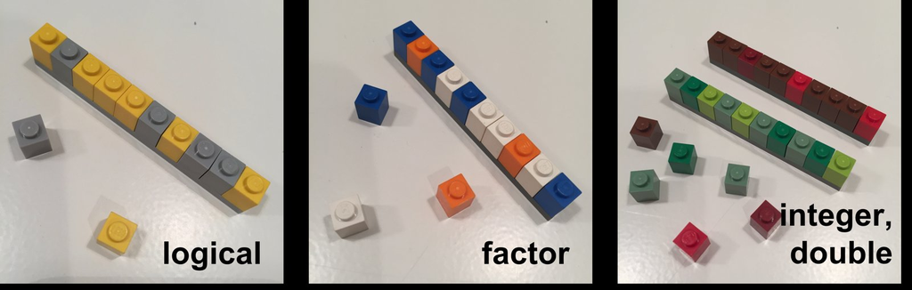

```
typeof(TRUE)     # logicaltypeof(2020L)    # integer: the Ltypeof(82.5)     # double: no Ltypeof("Mon")    # character: quotes
```

```
[1] "logical"
[1] "integer"
[1] "double"
[1] "character"
```

One vector, one type

`typeof()` tells you which one you have. The *factor* row (categories with fixed levels) is Monday's topic.

<html>
<hr>
</html>
**Image:** Jenny Bryan, [lego-rstats](https://github.com/jennybc/lego-rstats#readme).

# A Self-Assessment for Type Checking

<countdown-timer class="countdown" id="timer_bc37b82f" minutes="2" seconds="0" update-every="1" tabindex="0" style="top:0;right:0;--countdown-font-size:2em;"></countdown-timer>

.panel[Game

Six columns from the Cincinnati crash file, seven rows drawn at random. For every column: **logical, integer, double, or character?** Connect them on the next tab.

| instanceid | crashdate | dayofweek | age | latitude_x | injuries |
| --- | --- | --- | --- | --- | --- |
| 46619FB1 | 2025-11-10 08:53:00 | MON | 47 | 39.138116 | 4 - POSSIBLE INJURY |
| 0307C584 | 2025-09-08 15:50:00 | MON | 32 | 39.160639 | 5 - NO APPARENTY INJURY |
| 09803D2E | 2025-07-27 12:24:00 | SUN | 23 | 39.137162 | 5 - NO APPARENTY INJURY |
| A0583304 | 2025-10-24 20:40:00 | FRI | 32 | 39.128541 | 5 - NO APPARENTY INJURY |
| 2DBB2FF7 | 2025-09-12 12:42:00 | FRI | BB | 39.08662 | 5 - NO APPARENTY INJURY |
| F9B159B9 | 2025-09-20 14:52:00 | SAT | 45 | 39.101339 | 5 - NO APPARENTY INJURY |
| 7B5B1C68 | 2025-10-06 10:18:00 | MON | 27 | 39.196296 | 5 - NO APPARENTY INJURY |

`instanceid` is shortened to its first 8 characters to fit. `NA` means the value is missing.

.panel[Connect

Drag from a column on the left to a type on the right (or click one, then the other). Each column gets exactly one type. Then press **Check**.

.panel[Answer

<details style="margin-top:4px;"><summary style="cursor:pointer; font-weight:700; color:#c3142d; font-size:16px;">Click to reveal the types</summary>

```
tibble::enframe(sapply(six, typeof),                name = "column", value = "type")
```

```
# A tibble: 6 × 2
  column     type
  <chr>      <chr>
1 instanceid character
2 crashdate  double
3 dayofweek  character
4 age        character
5 latitude_x double
6 injuries   character
```

Two gotchas

**`crashdate` is a double.** readr recognized the date-time and stores it as seconds since 1970 with a date-time label on top. Dates are numbers in a costume, which is why you can subtract them.

**`age` is character.** Besides blanks, the column contains the codes `BB`, `NN`, `NB`. One text value anywhere in a column turns the whole column into character, and every number in it stops being a number. Cleaning that is a Class 03 job.

</details>

.panel[Discussion

- Notes from our class discussion (Use Chrome as your browser to edit this part of the page)

# From Vectors to a Data Frame

```
fsb = tibble::tibble(  day     = names(crashes_by_day),  crashes = crashes_by_day,  busy    = crashes_by_day > 2000)fsb
```

```
# A tibble: 7 × 3
  day   crashes busy
  <chr>   <dbl> <lgl>
1 Mon      2020 TRUE
2 Tue      2241 TRUE
3 Wed      2327 TRUE
4 Thu      2285 TRUE
5 Fri      2380 TRUE
6 Sat      1866 FALSE
7 Sun      1664 FALSE
```

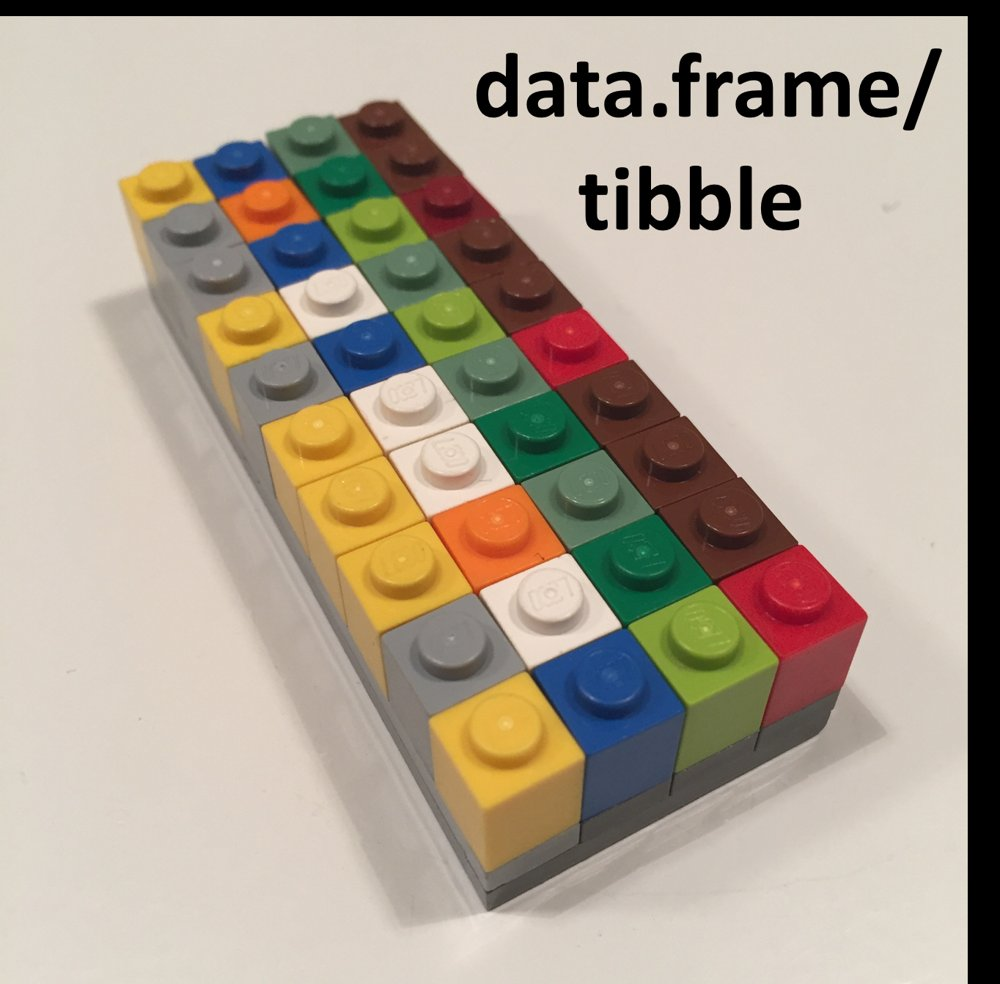

Vectors standing side by side

Each **column** is one vector with one type (`<chr>`, `<dbl>`, `<lgl>` in the header). All columns have the **same length**, so every row lines up.

The crash file is the same thing with 30,125 rows and 13 columns. `tibble` is the tidyverse's data frame: same object, tidier printing. **Monday:** taking these apart (pick a column, pick rows, and lists).

<html>
<hr>
</html>
**Image:** Jenny Bryan, [lego-rstats](https://github.com/jennybc/lego-rstats#readme).

# Functions: Name and Arguments

```
mean(x = crashes_by_day)              # by namemean(crashes_by_day, 0.2)             # by positionmean(x = crashes_by_day, trim = 0.2)  # both
```

```
[1] 2111.857
[1] 2147.8
[1] 2147.8
```

**House rule:** name every argument. `mean(x = crashes_by_day, trim = 0.2)` reads the same in six months and never depends on remembering the order.

<countdown-timer class="countdown" id="timer_5d651254" minutes="2" seconds="0" update-every="1" tabindex="0" style="top:0;right:0;--countdown-font-size:2em;"></countdown-timer>

.panel[Help page

In the Console, run `?mean`. The Help pane opens. Answer:

**1.** In *Usage*, which arguments have a default value?

**2.** In *Arguments*, what does `trim = 0.2` remove?

**3.** Try `mean(c(1, 2, NA))`, then `mean(c(1, 2, NA), na.rm = TRUE)`. What did `na.rm` change?

.panel[Discussion

- Notes from our class discussion (Use Chrome as your browser to edit this part of the page)

# Functions from Packages

Base R ships with `mean()`, `sum()`, `c()`. Almost everything else comes in a **package**, and a package has to make two trips before you can use it.

1 · CRAN, on the internet

The app store for R

24,780 packages, free, reviewed, one download away. `dplyr`, `ggplot2`, `readr` live here.

install.packages("dplyr")

→

once per computer,  
in the Console

2 · Your computer

The library folder

Installed means downloaded to this machine. It sits on disk, not in R. Your laptop needs its own copy.

dplyr::count()

or

library(dplyr)

→

every session,  
at the top of the script

3 · Your R session

Ready to use

A fresh session knows nothing until you say which package a function comes from. `count()` alone: error. `dplyr::count()`: works.

**Why we write `pkg::fun()` in this course.** It reads like a citation: anyone can see where `count()` came from. Two packages with the same function name cannot collide. And it works even when you forgot `library()`.

<html>
<hr>
</html>
**Package count:** [CRAN, Contributed Packages](https://cran.r-project.org/web/packages/), checked Aug 25, 2026.

# Recap

# Summary of Main Points

By now, you should be able to do the following:

- **Explain** why a script beats a spreadsheet for **reproducible analysis**: the steps are written down, run in order, and run again on new data after changing one line.

- **Use** the Git verbs **clone, commit, push**, and say what a **repository** is and what **GitHub** adds to Git.

- **Set up** an **RStudio project** inside a repository so every path is relative to it.

- **Read and write** basic R: **objects** and assignment, **vectors** and their **types**, **data frames**, **functions** with named arguments, and **`pkg::fun()`**.

**Skills you practiced along the way:** reading an error message (`object 'x' not found`), reading a **diff**, telling **text files** from binary files, and checking `typeof()` before trusting a column.

# Before You Go

Which concept from today still needs clarification? Vote, and we go through the top answers before you leave.

[interactive chart not shown]

# 📝 Review and Clarification 📝

1. **Class Notes**: Take some time to revisit your class notes for key insights/concepts.

2. **Zoom Recording**: The recording of today's class will be made available on Canvas approximately 3-4 hours after the session ends.

3. **AI Recaps:** make your own with Gemini's NotebookLM, as I did for Class 01 (see the right).

4. **Questions**: Do not let confusion pile up.

Make your own recap in NotebookLM

1. Go to notebooklm.google.com and sign in with your Miami Google account.
2. Add today's slide deck as a source: paste the deck's address from Canvas as a **Website** source.
3. Click **Audio Overview** for a podcast, or **Video Overview** for a narrated video. Both take a few minutes to generate.

What it looks like: the Class 01 [video](https://www.youtube.com/watch?v=sys7WBk0iew) and [podcast](https://drive.google.com/file/d/1lt6hqrMuW8JOy9ilvkT5NVlPABowj7SE/view). Treat them as a study aid, not a substitute for the slides: the AI summarizes what is on the page and can misstate details.

# 🎯 Assignments 🎯

- **[Assignment 02](https://miamioh.instructure.com/courses/258169/assignments/3600723/): Make the Portfolio Yours.** Clone the `portfolio` repository ChatISA created for you, make it an RStudio project, push one mechanical commit, then edit every sentence you would not say to a recruiter, add your contact links, and reorder the sections. Submit the address of the live site.

- **[Assignment 03](https://miamioh.instructure.com/courses/258169/assignments/3600724/): Git, RStudio, and Your Portfolio.** A short Canvas quiz on what you just did. Take it after your portfolio edits are pushed; GitHub Desktop's History tab answers half of it.

**Do not regenerate the site on ChatISA.** Generating again overwrites the repository and erases your edits. From here on, the repository is yours: edit, commit, push.